# Weather Conditions and their Influence on Human Mobility Patterns

## Influence of Weather on Walking - ArcGIS Earth trajectories analysis

Now we switch from the timeline data to the ArcGIS Earth data, since Google timeline does not allow for precise movement parameter calculations due to the coarse sampling rate.

### Segmentation of trajectories

First we split our trajectories into segments of stops and moves using a moving window. Since ArcGIS Earth has a very fine sampling rates (seconds) and we sometimes let the tracking run for a whole day, a lot of the fixes are stops and will not be needed for further analysis.  
Following a similar procedure as in these studies (Guo et al. (2018))(Bonavita, Guidotti, and Nanni (2022)), we employed spatial and temporal tresholds to classify movement and non-movement. We classified the segment as “movement” if the distance travelled in 1 timestep was more than 5 meters within a time of 30 seconds. This allows for certain minimal movement, such as being in crowded pedestrian areas, without being automatically being classified as stop.

```r
# define function
difftime_secs <- function(later, now){
    as.numeric(difftime(later, now, units = "secs"))
}
```

```r
# define two timestamps for function using lead
later <- lead(tracks_lv95$timestamp)
now <- tracks_lv95$timestamp

tracks_lv95$timelag <- difftime_secs(later, now)
```

```r
# sort after timestamp
tracks_lv95 <- tracks_lv95 |>
  arrange(timestamp)
```

```r
# compute distance and time difference
tracks_lv95 <- tracks_lv95 |>
  mutate(
    step_dist = as.numeric(st_distance(geometry, lead(geometry), by_element = TRUE)),
    step_time = as.numeric(difftime(lead(timestamp), timestamp, units = "secs"))
  )
```

```r
# define threshold of moving window, movement if distance of 1 step more than 5 meters in a time of less than 30 seconds
tracks_lv95 <- tracks_lv95 |>
  mutate(
    moving_step = step_dist > 5 & step_time < 30
  )
```

```r
# assign new segment_id each time transition from stop to move or vice versa
# to connect the still separate points into segments, with support of Chatgpt
tracks_lv95 <- tracks_lv95 |>
  mutate(
    change = moving_step != lag(moving_step, default = first(moving_step)),
    segment_id = cumsum(change)
  )
```

```r
# calculate for each segment starting time, end time, duration, geometry, speed
segments <- tracks_lv95 |>
  group_by(segment_id, moving_step) |>
  summarise(
    start_time = first(timestamp),
    end_time = last(timestamp),

    duration = as.numeric(
      difftime(last(timestamp), first(timestamp), units = "secs")
    ),

    distance = sum(step_dist, na.rm = TRUE),

    speed = ifelse(duration > 0, distance / duration, NA_real_),

    speed_kmh = speed * 3.6,

    n_points = n(),
    geometry = st_union(geometry),
    .groups = "drop"
  )
```

```r
# classify segments to Movement or not (Stop)
segments <- segments |>
  mutate(type = ifelse(moving_step, "MOVE", "STOP"))
```

**All**

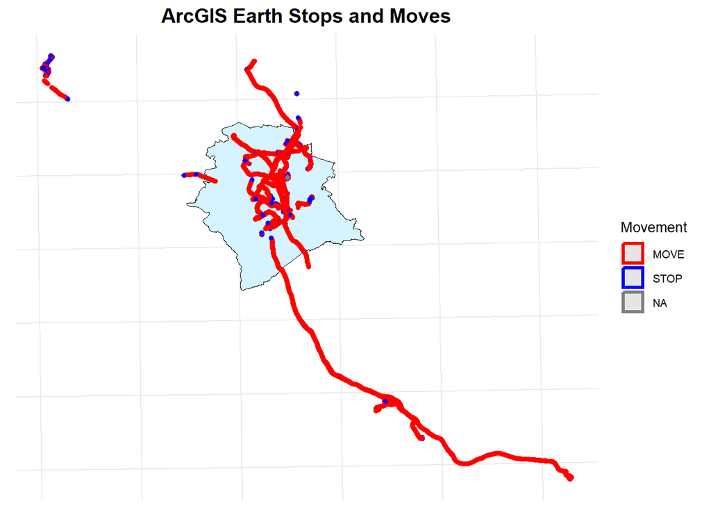

```r
# visualize stops and moves together with city boundary
ggplot() +
  geom_sf(data = stadtgrenze, fill = "#D5F4FF", color = "black") +

  geom_sf(data = segments, aes(color = type), size = 1.2) +

  scale_color_manual(values = c("STOP" = "blue", "MOVE" = "red")) +

  coord_sf(crs = crs_lv95) +

  labs(
    title = "ArcGIS Earth Stops and Moves",
    color = "Movement",
    x = "Easting [m]",
    y = "Northing [m]") +

  theme_minimal() +

  theme(
    plot.title = element_text(size = 14, face = "bold", hjust = 0.5),
    legend.title = element_text(size = 10),
    legend.text = element_text(size = 8),
    axis.text = element_blank(),
    axis.title = element_blank()
    )
```

**Zurich**

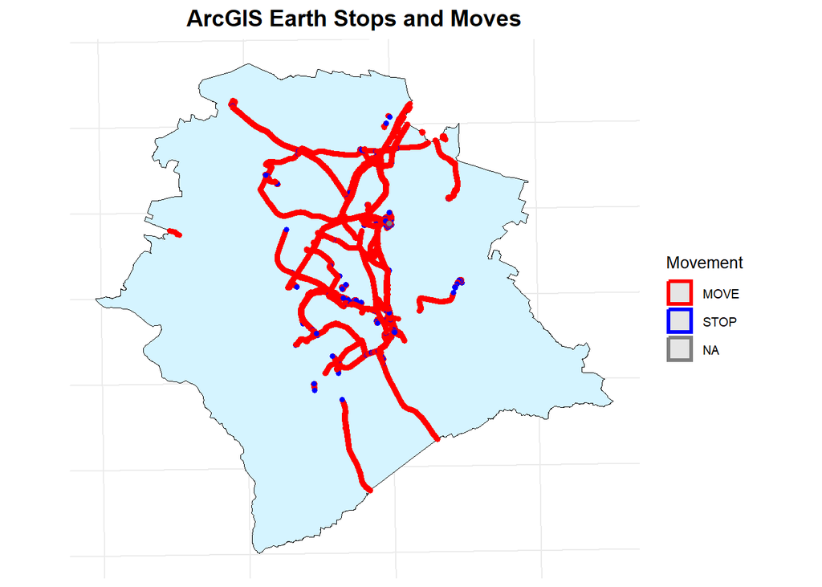

```r
# visualize stops and moves inside Zurich together with city boundary
ggplot() +
  geom_sf(data = stadtgrenze, fill = "#D5F4FF", color = "black") +

  geom_sf(data = segments |>
            st_intersection(stadtgrenze),
          aes(color = type), size = 1.2) +

  scale_color_manual(values = c("STOP" = "blue", "MOVE" = "red")) +

  coord_sf(crs = crs_lv95) +

  labs(
    title = "ArcGIS Earth Stops and Moves",
    color = "Movement",
    x = "Easting [m]",
    y = "Northing [m]") +

  theme_minimal() +

  theme(
    plot.title = element_text(size = 14, face = "bold", hjust = 0.5),
    legend.title = element_text(size = 10),
    legend.text = element_text(size = 8),
    axis.text = element_blank(),
    axis.title = element_blank()
    )
```

### Speed Exploratory Analysis

```r
# distribution of speed to cut boundaries
quantile(segments$speed_kmh[segments$moving_step],
         probs=c(0.5,0.9,0.95, 0.98),
         na.rm = TRUE)
```

```
       50%        90%        95%        98%
  9.981582  45.577325  80.805970 203.669696
```

```r
# trim upper tail, with support of ChatGPT
upper <- quantile(segments$speed_kmh, 0.975, na.rm = TRUE)

segments_trim <- segments |>
  filter(speed_kmh <= upper)
```

As can be seen in the plots below, the majority of the fixes have a speed below 20 km/h, indicating high shares of foot travel or slow transport.

**Boxplot**

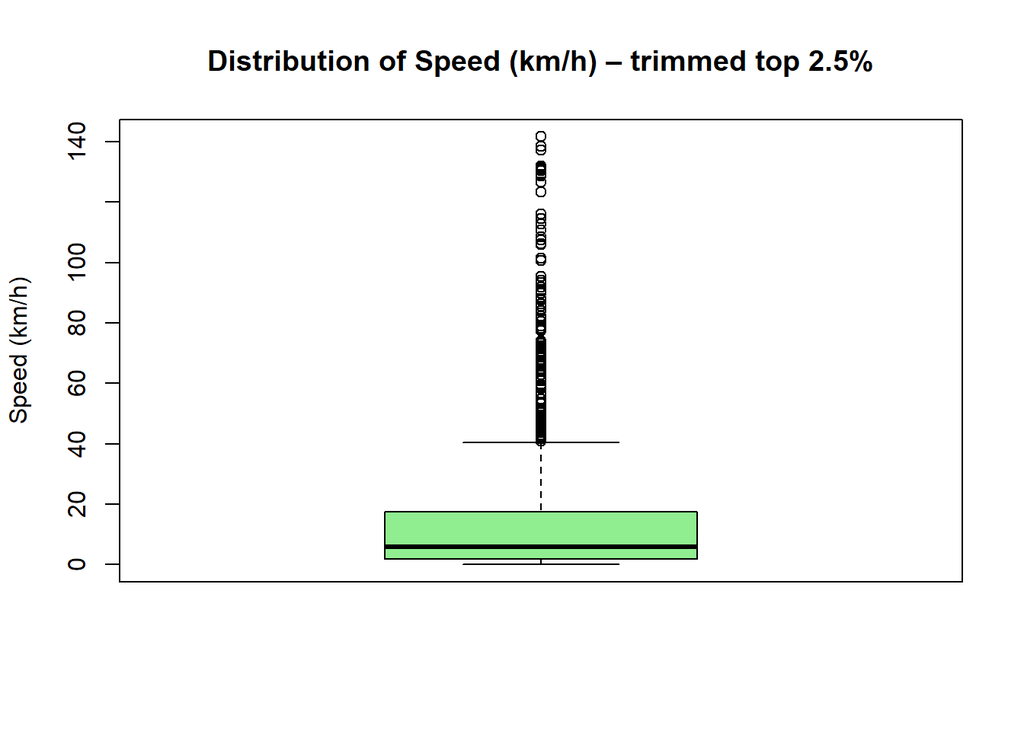

```r
# boxplot for distribution
boxplot(
  segments_trim$speed_kmh,
  main = "Distribution of Speed (km/h) – trimmed top 2.5%",
  ylab = "Speed (km/h)",
  col = "lightgreen"
)
```

**Histogram**

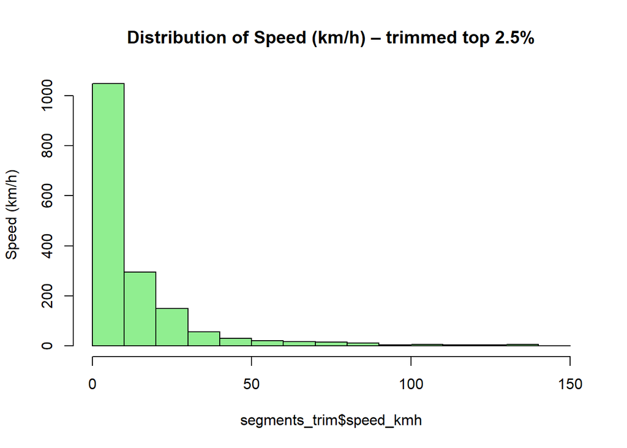

```r
# histogram for distribution
hist(
  segments_trim$speed_kmh,
  main = "Distribution of Speed (km/h) – trimmed top 2.5%",
  ylab = "Speed (km/h)",
  col = "lightgreen"
)
```

### Travel Mode Detection - Walking

```r
# In transportation planning, free flow pedestrian walking speed is assumed to be between 0.8 m/s and 1.5 m/s or 3 to 7 km/h. In our case, slower walking speeds could be possible since the city of Zurich can be rather densely packed and free flow speed might not be achieved. This is why we extended the lower threshold.

# create only walking segments (speed between 1 and 7 km/h)
walking_segments <- segments |>
  filter(segments$speed_kmh < 7 & segments$speed_kmh > 1 )
```

### Construct Voronoi Polygons around meteoblue Stations

```r
# To assign each segment the nearest meteoblue measuring station, we construct Voronoi polygons, following the same approach as before.

# create geometry out of coordinates for meteoblue_stations
meteoblue_sf <- meteoblue_stations |>
  st_as_sf(coords=c("lonDecimal", "latDecimal"), crs = crs_wgs84)

meteoblue_sf <- st_transform(meteoblue_sf, crs = crs_lv95)
```

```r
# create union of all station points and set city extent
pts_union <- st_union(st_geometry(meteoblue_sf))

envelope_zurich <- st_as_sfc(st_bbox(stadtgrenze))
```

```r
# create Voronoi tesselation and extract polygons out of it, with support of ChatGPT
voronoi_meteoblue <- st_voronoi(pts_union, envelope=envelope_zurich)

voronoi_polygons <- st_collection_extract(
  voronoi_meteoblue,
  "POLYGON"
)
# convert to sf object
voronoi_sf <- st_sf(
  geometry = st_cast(voronoi_polygons, "POLYGON")
)
```

```r
# assign station attributes to polygons
voronoi_sf$locationID <- meteoblue_sf$locationID

# clip to Zurich city boundary
voronoi_clipped_meteoblue <- st_intersection(
  voronoi_sf,
  stadtgrenze
)
```

```r
# join between voronoi stations and meteoblue weather data
voronoi_weather <- voronoi_clipped_meteoblue |>
  left_join(
    meteoblue_weather_data,
    by = "locationID"
  )
```

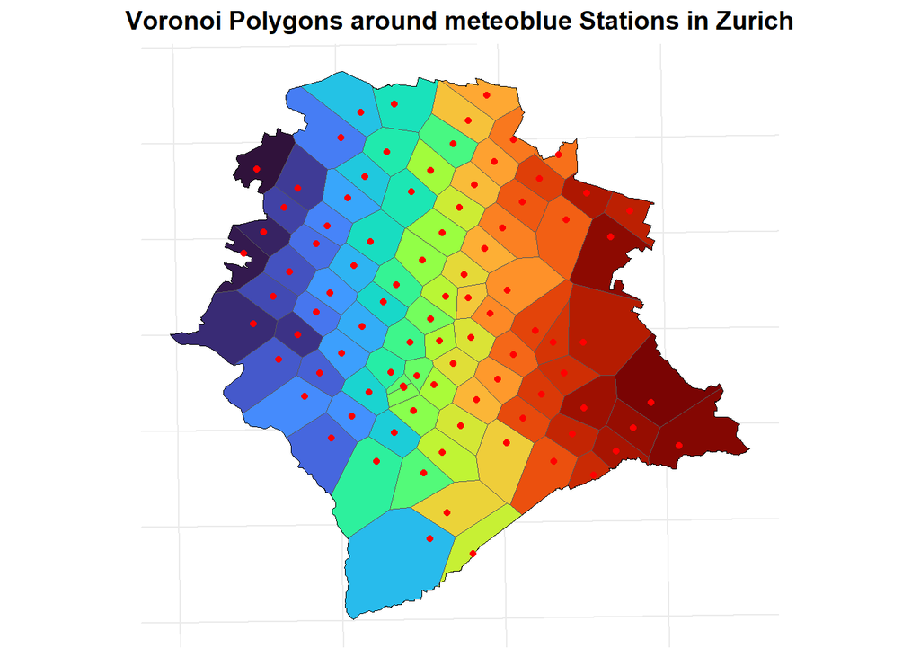

```r
# visualisation
ggplot() +
  geom_sf(data = voronoi_clipped_meteoblue, aes(fill = locationID)) +

  geom_sf(data = stadtgrenze, fill = NA, color = "black") +

  geom_sf(data = meteoblue_sf, color = "red") +

  coord_sf(crs = crs_lv95) +

  scale_fill_viridis_d(option = "turbo") +

  guides(fill = "none") +

  labs(
    title = "Voronoi Polygons around meteoblue Stations in Zurich",
    fill = "Station",
    x = "Easting [m]",
    y = "Northing [m]"
  ) +

  theme_minimal() +

  theme(
    plot.title = element_text(size = 14, face = "bold", hjust = 0.5),
    legend.title = element_text(size = 10),
    legend.text = element_text(size = 8),
    axis.text = element_blank(),
    axis.title = element_blank()
  )
```

### Assign Segments to Voronoi Polygons

```r
# only look at point instead of segment
segment_points <- walking_segments |>
  st_cast("POINT")

# join with intersect
segment_points_weather <- st_join(
  segment_points,
  voronoi_clipped_meteoblue["locationID"],
  join = st_intersects
)

# aggregate back
meteoblue_segments <- segment_points_weather |>
  group_by(segment_id, locationID) |>
  summarise(geometry = st_union(geometry))

# clip to extent of Zurich
meteoblue_segments_clipped <- st_intersection(
  meteoblue_segments,
  stadtgrenze
)
```

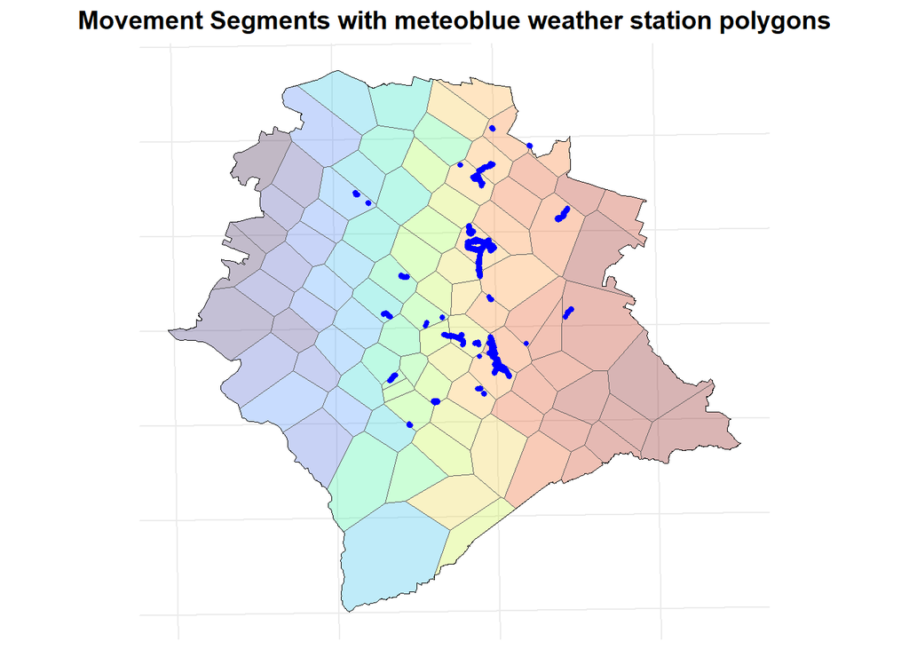

```r
# visualize Movement Segments with meteoblue weather station polygons
ggplot() +
  geom_sf(data = voronoi_clipped_meteoblue, aes(fill = locationID), alpha = 0.3) +

  geom_sf(data = stadtgrenze, fill = NA, color = "black") +

  geom_sf(data = meteoblue_segments_clipped, color = "blue", size = 1) +

  coord_sf(crs = crs_lv95) +

  scale_fill_viridis_d(option = "turbo") +

  guides(fill = "none") +

  labs(
    title = "Movement Segments with meteoblue weather station polygons",
    x = "Easting",
    y = "Northing"
  ) +

  theme_minimal() +

  theme(
    plot.title = element_text(size = 14, face = "bold", hjust = 0.5),
    legend.title = element_text(size = 10),
    legend.text = element_text(size = 8),
    axis.text = element_blank(),
    axis.title = element_blank()
  )
```

### Temporal Join of Weather Data and Walking Segments

```r
# find most representative time (midtime) of each segment
segments <- segments |>
  mutate(
    mid_time = start_time + (end_time - start_time) / 2
  )
```

```r
# set as posix datetime object
meteoblue_weather_data <- meteoblue_weather_data |>
  mutate(timestamp = as.POSIXct(timestamp))
```

```r
# add spatial information to segments
segments_spatial <- st_join(
  segments,
  meteoblue_segments["locationID"],
  join = st_intersects
)
```

```r
# clean
segments_clean <- segments_spatial |>
  st_drop_geometry()
```

```r
segments_weather <- segments_clean |>
  left_join(meteoblue_weather_data, by = "locationID") |>
  mutate(
    time_diff = abs(as.numeric(difftime(mid_time, timestamp, units = "mins")))
  ) |>
  group_by(segment_id) |>
  slice_min(time_diff, n = 1, with_ties = FALSE) |>
  ungroup()
```

```r
# filter unrealistic values
segments_weather_clean <- segments_weather |>
  filter(time_diff <= 120) |>
  filter(
    speed_kmh >= quantile(speed_kmh, 0.02, na.rm = TRUE),
    speed_kmh <= quantile(speed_kmh, 0.98, na.rm = TRUE)
  )
```

## Analyze effect of Precipitation

To analzye the effect of precipitation on walking speed, we opted for two different spatial and temporal scales of the weather data (small cross-scale analysis (Laube and Purves (2011))). First, conducted an analysis with weather data on a city-level. Second, we applied the same procedure, but with weather data on a station-level.

```r
# clean weather_hourly_df
rain_hourly_df <- weather_hourly_df |>
  filter(Parameter == "RainDur")
```

```r
# determine representative time for segment
walking_segments <- walking_segments |>
  mutate(
    mid_time = start_time + (end_time - start_time) / 2
  )
```

### A) City-level Analysis

```r
# We decided on using the hourly weather data since it resembles reality closer than daily weather data.

# timestamp set as datetime object
rain_city_hourly <- weather_hourly_df |>
  filter(Parameter == "RainDur") |>
  mutate(timestamp = as.POSIXct(Datum, tz = "Europe/Zurich")) |>
  group_by(timestamp) |>
  summarise(rain = mean(Wert, na.rm = TRUE), .groups = "drop")
```

```r
# temporal join, merge all segments with all weather data and keep closest
analysis_city <- walking_segments |>
  st_drop_geometry() |>
  mutate(mid_time = as.POSIXct(mid_time, tz = "Europe/Zurich")) |>
  crossing(rain_city_hourly) |>
  mutate(time_diff = abs(as.numeric(difftime(mid_time, timestamp, units = "mins")))) |>
  group_by(segment_id) |>
  slice_min(time_diff, n = 1) |>
  ungroup() |>
  filter(!is.na(rain))
```

### B) Station-level Analysis

```r
# join segment with nearest station first
segments_station <- st_join(
  walking_segments,
  voronoi_clipped["ID"],
  join = st_nearest_feature
)
```

```r
segments_weather_rain <- segments_station |>
  st_drop_geometry() |>
  left_join(
    rain_hourly_df,
    by = c("ID" = "Standort")
  ) |>
  mutate(
    timestamp = as.POSIXct(Datum, tz = "Europe/Zurich"),
    time_diff = abs(as.numeric(
      difftime(mid_time, timestamp, units = "mins")
    ))
  ) |>
  group_by(segment_id) |>
  slice_min(time_diff, n = 1, with_ties = FALSE) |>
  ungroup()
```

```r
# temporal join, with segment merging with rain weather data
analysis_station <- segments_station |>
  st_drop_geometry() |>
  left_join(rain_hourly_df, by = c("ID" = "Standort")) |>
  mutate(time_diff = abs(as.numeric(difftime(mid_time, as.POSIXct(Datum), units = "mins")))) |>
  group_by(segment_id) |>
  slice_min(time_diff, n = 1) |>
  ungroup() |>
  filter(!is.na(Wert))
```

```r
# define rain vs. no rain
segments_weather_rain <- segments_weather_rain |>
  mutate(
    rain_flag = ifelse(Wert > 0, "rain", "no_rain")
  )
```

```r
# two stations have all NA-values => no rainfall data collection
segments_weather_rain |>
  filter(is.na(Wert)) |>
  count(ID)
```

```
# A tibble: 2 × 2
  ID                        n
  <chr>                 <int>
1 Zch_Heubeeribüel        186
2 Zch_Rosengartenbrücke   162
```

```r
analysis_data <- analysis_station |>
  mutate(rain_flag = ifelse(Wert > 0, "rain", "no_rain"))
```

```r
# group if rain or not and analyze speed respectively
analysis_data |>
  group_by(rain_flag) |>
  summarise(
    mean_speed = mean(speed_kmh, na.rm = TRUE),
    median_speed = median(speed_kmh, na.rm = TRUE),
    sd_speed = sd(speed_kmh, na.rm = TRUE),
    n = n()
  )
```

```
# A tibble: 2 × 5
  rain_flag mean_speed median_speed sd_speed     n
  <chr>          <dbl>        <dbl>    <dbl> <int>
1 no_rain         4.19         4.39     1.54   213
2 rain            3.68         3.47     1.66    16
```

# Results

In this chapter we will present the performed statistical tests as well as their results and implications. Thanks to the different weather datasets and our own tracking data, coming from two different sources, we were able to achieve results that can later be used to discuss our research questions.

## Statistical Analysis Movement Space vs. Weather

After preparing the data and creating all necessary auxiliary elements we are now finally able to test our hypothesis.

### A) Daily - Voronoi Polygon

**Temperature**

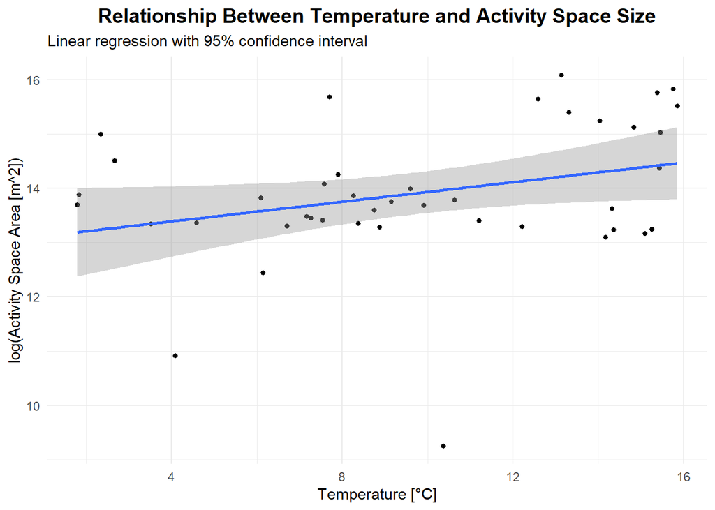

```r
# visualise the variable Temperature
ggplot(daily_hulls_weather, aes(x = Temperature, y = log(area_m2))) +

  geom_point(size = 1.2) +

  geom_smooth(method = "lm", se = TRUE, linewidth = 1) +

  labs(
    x = "Temperature [°C]",
    y = "log(Activity Space Area [m^2])",
    title = "Relationship Between Temperature and Activity Space Size",
    subtitle = "Linear regression with 95% confidence interval") +

  theme_minimal() +

  theme(
    plot.title = element_text(size = 14, face = "bold", hjust = 0.5),
    legend.title = element_text(size = 10),
    legend.text = element_text(size = 8)
    )
```

**Rain Duration**

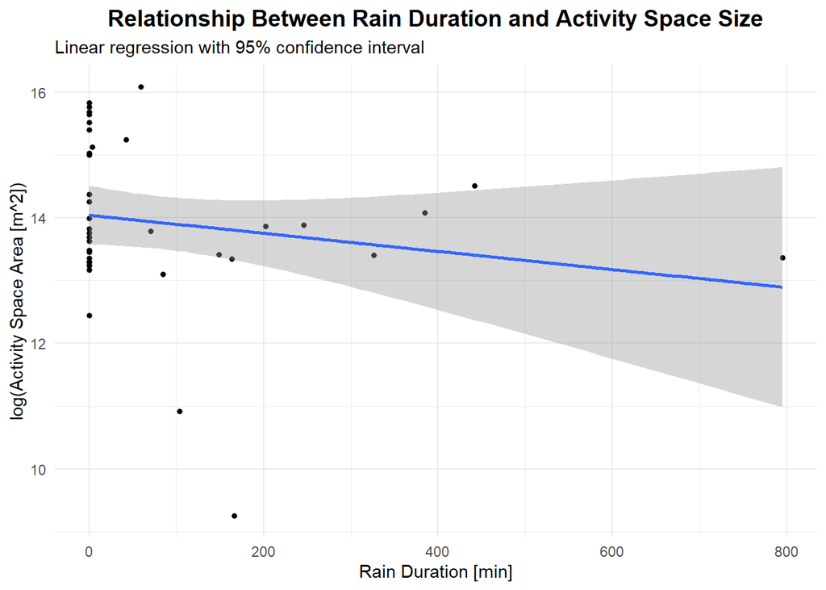

```r
# visualise the variable RainDur
ggplot(daily_hulls_weather, aes(x = RainDur, y = log(area_m2))) +

  geom_point(size = 1.2) +

  geom_smooth(method = "lm", se = TRUE, linewidth = 1) +

  labs(
    x = "Rain Duration [min]",
    y = "log(Activity Space Area [m^2])",
    title = "Relationship Between Rain Duration and Activity Space Size",
    subtitle = "Linear regression with 95% confidence interval") +

  theme_minimal() +

  theme(
    plot.title = element_text(size = 14, face = "bold", hjust = 0.5),
    legend.title = element_text(size = 10),
    legend.text = element_text(size = 8)
    )
```

```r
# linear model with log(area)
lm1 <- lm(log(area_m2) ~ Temperature + RainDur, data = daily_hulls_weather)
```

```r
# full model summary (R^2, adjusted R^2, p-values, residual std error)
summary(lm1)
```

```
Call:
lm(formula = log(area_m2) ~ Temperature + RainDur, data = daily_hulls_weather)

Residuals:
    Min      1Q  Median      3Q     Max
-4.6620 -0.5310 -0.0180  0.8015  1.9240

Coefficients:
              Estimate Std. Error t value Pr(>|t|)
(Intercept) 13.0708461  0.6248266  20.919   <2e-16 ***
Temperature  0.0888042  0.0532322   1.668    0.104
RainDur     -0.0004278  0.0014005  -0.305    0.762
---
Signif. codes:  0 '***' 0.001 '**' 0.01 '*' 0.05 '.' 0.1 ' ' 1

Residual standard error: 1.278 on 37 degrees of freedom
  (3 Beobachtungen als fehlend gelöscht)
Multiple R-squared:  0.09951,   Adjusted R-squared:  0.05084
F-statistic: 2.044 on 2 and 37 DF,  p-value: 0.1438
```

```r
# delete comments if one wants to inspect the plots closer
#par(mfrow = c(1, 1))
#plot(lm1, which = 1)  # Residuals vs Fitted
#plot(lm1, which = 2)  # Q-Q plot
#plot(lm1, which = 3)  # Scale-Location
#plot(lm1, which = 5)  # Residuals vs Leverage
```

This first model is not statistically significant as a whole (F-statistic p = 0.1438). Meaning Temperature and RainDur together do explain some variation in activity space but the low R^2 (0.1) and adjusted R^2 (0.05) suggests other factors (e.g. day of week, work/leisure day, season) that influence activity space more than weather.

There is a suggestive positive trend with Temperature, but we cannot confidently reject H0.

### B) Daily - Field

**Temperature**

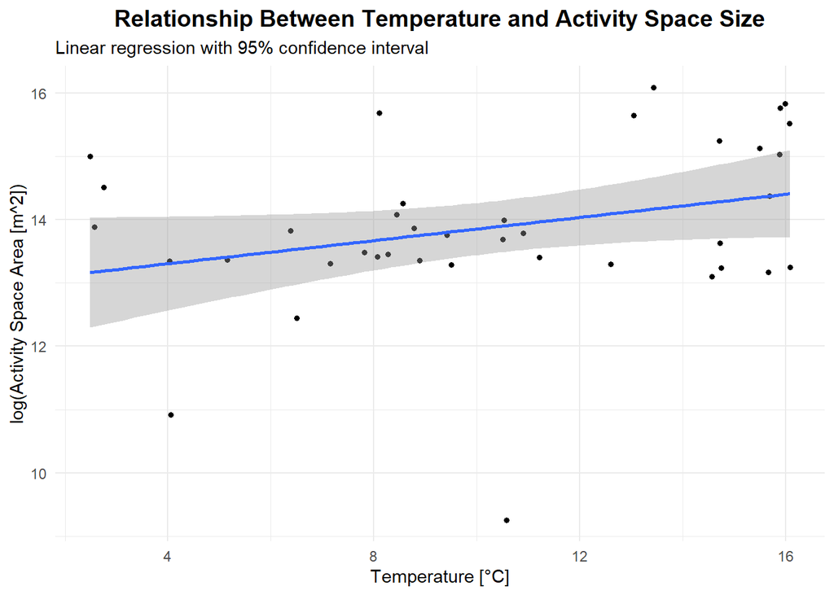

```r
# visualise the variable Temperature
ggplot(daily_hulls_weather_field, aes(x = Temperature, y = log(area_m2))) +

  geom_point(size = 1.2) +

  geom_smooth(method = "lm", se = TRUE, linewidth = 1) +

  labs(
    x = "Temperature [°C]",
    y = "log(Activity Space Area [m^2])",
    title = "Relationship Between Temperature and Activity Space Size",
    subtitle = "Linear regression with 95% confidence interval") +

  theme_minimal() +

  theme(
    plot.title = element_text(size = 14, face = "bold", hjust = 0.5),
    legend.title = element_text(size = 10),
    legend.text = element_text(size = 8)
    )
```

**Rain Duration**

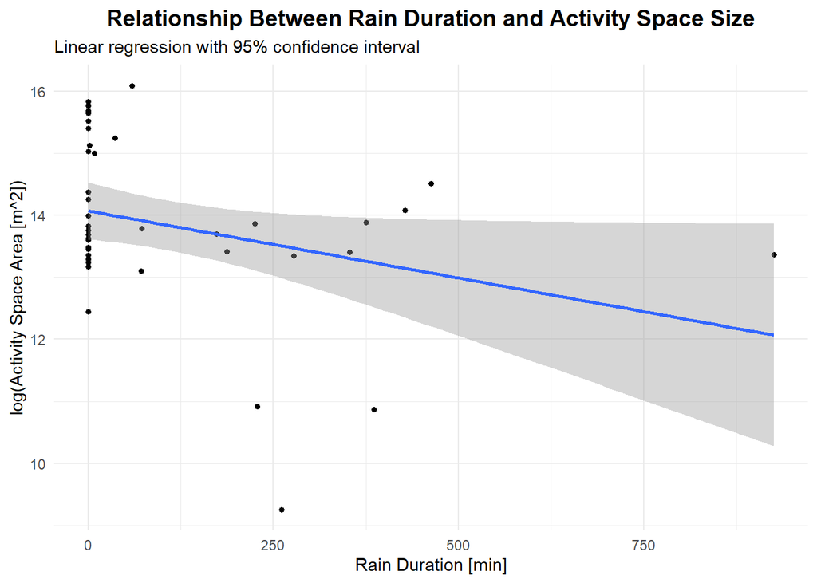

```r
# visualise the variable RainDur
ggplot(daily_hulls_weather_field, aes(x = RainDur, y = log(area_m2))) +

  geom_point(size = 1.2) +

  geom_smooth(method = "lm", se = TRUE, linewidth = 1) +

  labs(
    x = "Rain Duration [min]",
    y = "log(Activity Space Area [m^2])",
    title = "Relationship Between Rain Duration and Activity Space Size",
    subtitle = "Linear regression with 95% confidence interval") +

  theme_minimal() +

  theme(
    plot.title = element_text(size = 14, face = "bold", hjust = 0.5),
    legend.title = element_text(size = 10),
    legend.text = element_text(size = 8)
    )
```

We see the same pattern with our new field (IDW) approach.

```r
# linear model with log(area)
lm2 <- lm(log(area_m2) ~ Temperature + RainDur, data = daily_hulls_weather_field)
```

```r
# full model summary (R^2, adjusted R^2, p-values, residual std error)
summary(lm2)
```

```
Call:
lm(formula = log(area_m2) ~ Temperature + RainDur, data = daily_hulls_weather_field)

Residuals:
    Min      1Q  Median      3Q     Max
-4.5100 -0.5640  0.0028  0.7882  1.9362

Coefficients:
              Estimate Std. Error t value Pr(>|t|)
(Intercept) 13.2111085  0.6711081  19.686   <2e-16 ***
Temperature  0.0733416  0.0548604   1.337    0.190
RainDur     -0.0008364  0.0012219  -0.684    0.498
---
Signif. codes:  0 '***' 0.001 '**' 0.01 '*' 0.05 '.' 0.1 ' ' 1

Residual standard error: 1.272 on 36 degrees of freedom
  (4 Beobachtungen als fehlend gelöscht)
Multiple R-squared:  0.1021,    Adjusted R-squared:  0.05226
F-statistic: 2.048 on 2 and 36 DF,  p-value: 0.1438
```

The P-value of the RainDur is quite lower than from lm1, indicating that the interpolation of precipitation duration is a more appropriate way of identifying a relationship between weather and movement.  
Furthermore, the R^2 and Adjusted R^2 values are slightly higher, meaning that our interpolated model explains a bit more of the values than the model with the Voronoi polygons.

### C) Hourly - Field

**Temperature**

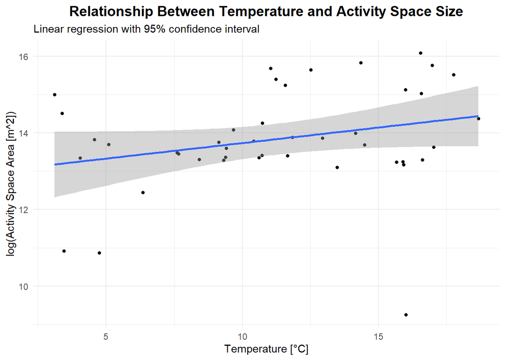

```r
# visualise the variable Temperature
ggplot(hourly_hulls_weather_field, aes(x = Temperature, y = log(area_m2))) +

  geom_point(size = 1.2) +

  geom_smooth(method = "lm", se = TRUE, linewidth = 1) +

  labs(
    x = "Temperature [°C]",
    y = "log(Activity Space Area [m^2])",
    title = "Relationship Between Temperature and Activity Space Size",
    subtitle = "Linear regression with 95% confidence interval") +

  theme_minimal() +

  theme(
    plot.title = element_text(size = 14, face = "bold", hjust = 0.5),
    legend.title = element_text(size = 10),
    legend.text = element_text(size = 8)
    )
```

**Rain Duration**

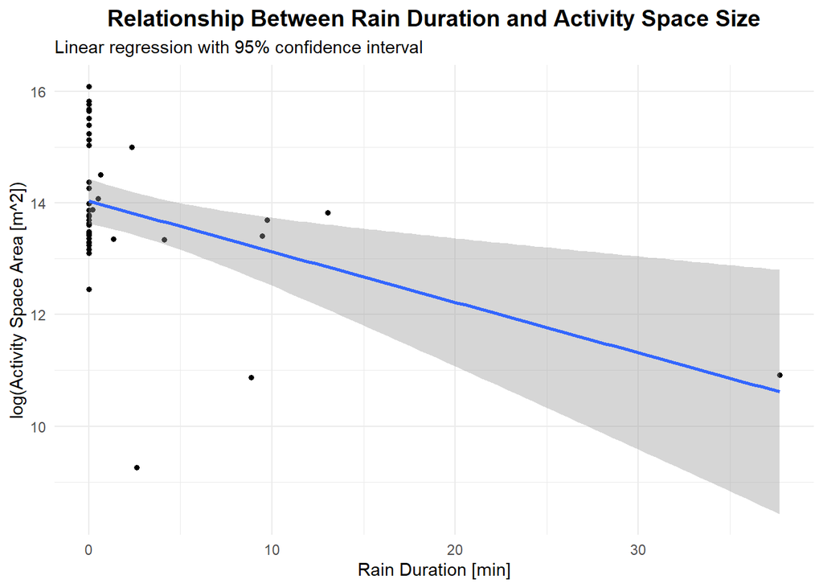

```r
# visualise the variable RainDur
ggplot(hourly_hulls_weather_field, aes(x = RainDur, y = log(area_m2))) +

  geom_point(size = 1.2) +

  geom_smooth(method = "lm", se = TRUE, linewidth = 1) +

  labs(
    x = "Rain Duration [min]",
    y = "log(Activity Space Area [m^2])",
    title = "Relationship Between Rain Duration and Activity Space Size",
    subtitle = "Linear regression with 95% confidence interval") +

  theme_minimal() +

  theme(
    plot.title = element_text(size = 14, face = "bold", hjust = 0.5),
    legend.title = element_text(size = 10),
    legend.text = element_text(size = 8)
    )
```

Again, we see the same visual pattern now with the hourly data.

```r
# linear model with log(area)
lm3 <- lm(log(area_m2) ~ Temperature + RainDur, data = hourly_hulls_weather_field)
```

```r
# full model summary (R^2, adjusted R^2, p-values, residual std error)
summary(lm3)
```

```
Call:
lm(formula = log(area_m2) ~ Temperature + RainDur, data = hourly_hulls_weather_field)

Residuals:
    Min      1Q  Median      3Q     Max
-4.6746 -0.5891 -0.1289  0.9238  1.9224

Coefficients:
            Estimate Std. Error t value Pr(>|t|)
(Intercept) 13.69650    0.61238  22.366   <2e-16 ***
Temperature  0.02802    0.04826   0.581   0.5647
RainDur     -0.08160    0.03394  -2.404   0.0209 *
---
Signif. codes:  0 '***' 0.001 '**' 0.01 '*' 0.05 '.' 0.1 ' ' 1

Residual standard error: 1.243 on 40 degrees of freedom
Multiple R-squared:  0.1893,    Adjusted R-squared:  0.1488
F-statistic:  4.67 on 2 and 40 DF,  p-value: 0.01504
```

We see a significant negative effect of RainDur on the movement area. The whole model explains much more of the variance since the Adjusted R^2 value is 0.15, meaning that 15% of the variance is explained with our model. Still, this is not a majority but a better model than the one with daily weather data.

If we have a look at for example the 24.03.2026 we can see the differences between aggregated daily and hourly weather data. The daily one says that on that date it was 8.1°C with a RainDur of 187 min, which is quite a lot. The hourly one says that it was 10.7°C with no rain. This means that while over the whole day, it rained quite a lot, we were only moving while it was not raining and slightly warmer, effectively being a great example for our research questions.

### D) 15 min - Field

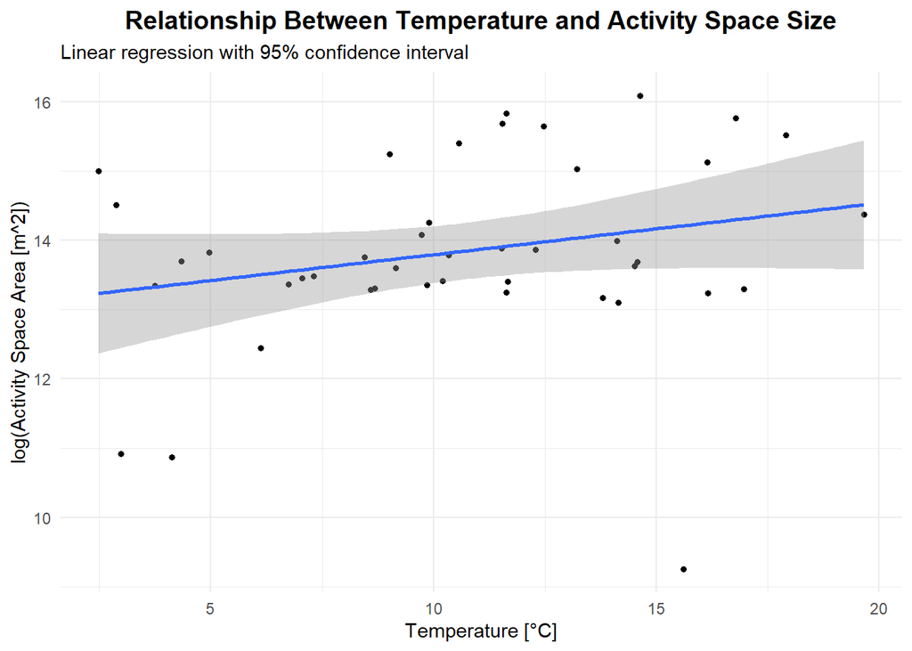

```r
# visualise the variable Temperature
ggplot(quarter_hourly_hulls_weather_field, aes(x = Temperature, y = log(area_m2))) +

  geom_point(size = 1.2) +

  geom_smooth(method = "lm", se = TRUE, linewidth = 1) +

  labs(
    x = "Temperature [°C]",
    y = "log(Activity Space Area [m^2])",
    title = "Relationship Between Temperature and Activity Space Size",
    subtitle = "Linear regression with 95% confidence interval") +

  theme_minimal() +

  theme(
    plot.title = element_text(size = 14, face = "bold", hjust = 0.5),
    legend.title = element_text(size = 10),
    legend.text = element_text(size = 8)
    )
```

Note: Here we only have 15 min temperature values and not 15 min rain values. This is why we earlier merged rain duration from hourly data into quarter-hourly temperature data.

```r
# linear model with log(area)
lm4 <- lm(log(area_m2) ~ Temperature + RainDur, data = quarter_hourly_hulls_weather_field_join)
```

```r
# full model summary (R^2, adjusted R^2, p-values, residual std error)
summary(lm4)
```

```
Call:
lm(formula = log(area_m2) ~ Temperature + RainDur, data = quarter_hourly_hulls_weather_field_join)

Residuals:
    Min      1Q  Median      3Q     Max
-4.6513 -0.5815 -0.1751  0.9693  1.9765

Coefficients:
            Estimate Std. Error t value Pr(>|t|)
(Intercept) 13.78406    0.58028  23.754   <2e-16 ***
Temperature  0.02200    0.04821   0.456   0.6505
RainDur     -0.08392    0.03360  -2.498   0.0167 *
---
Signif. codes:  0 '***' 0.001 '**' 0.01 '*' 0.05 '.' 0.1 ' ' 1

Residual standard error: 1.245 on 40 degrees of freedom
Multiple R-squared:  0.1867,    Adjusted R-squared:  0.146
F-statistic: 4.591 on 2 and 40 DF,  p-value: 0.01603
```

## Statistical Analysis - Influence of Weather on Walking

### Influence on Walking Speed

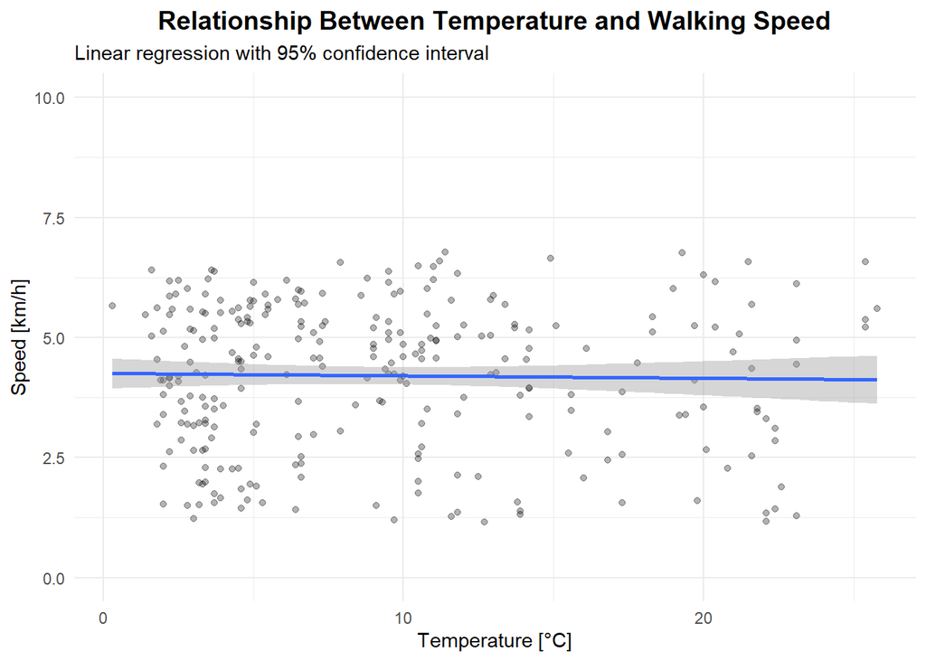

```r
# visualize
ggplot(segments_weather_clean, aes(x = value, y = speed_kmh)) +

  geom_point(alpha = 0.3) +

  geom_smooth(method = "lm", se = TRUE, linewidth = 1) +

  coord_cartesian(ylim = c(0, 10)) +

  labs(
    x = "Temperature [°C]",
    y = "Speed [km/h]",
    title = "Relationship Between Temperature and Walking Speed",
    subtitle = "Linear regression with 95% confidence interval") +

  theme_minimal() +

  theme(
    plot.title = element_text(size = 14, face = "bold", hjust = 0.5),
    legend.title = element_text(size = 10),
    legend.text = element_text(size = 8)
    )
```

```r
# trend analysis
trend <- lm(speed_kmh ~ value, data = segments_weather_clean)

summary(trend)
```

```
Call:
lm(formula = speed_kmh ~ value, data = segments_weather_clean)

Residuals:
    Min      1Q  Median      3Q     Max
-3.0406 -1.0729  0.2953  1.2193  2.6072

Coefficients:
             Estimate Std. Error t value Pr(>|t|)
(Intercept)  4.253933   0.161892  26.276   <2e-16 ***
value       -0.005095   0.014407  -0.354    0.724
---
Signif. codes:  0 '***' 0.001 '**' 0.01 '*' 0.05 '.' 0.1 ' ' 1

Residual standard error: 1.513 on 272 degrees of freedom
  (5 Beobachtungen als fehlend gelöscht)
Multiple R-squared:  0.0004597, Adjusted R-squared:  -0.003215
F-statistic: 0.1251 on 1 and 272 DF,  p-value: 0.7238
```

There is no relationship between walking speed and temperature when taking the whole dataset. This was to be expected, as shown in Introduction.

```r
# classification of different temperature groups
segments_weather_clean <- segments_weather_clean |>
  mutate(
    temp_group = cut(value,
                     breaks = quantile(value, probs = seq(0, 1, 0.25), na.rm = TRUE),
                     include.lowest = TRUE)
  )

lm(speed_kmh ~ temp_group, data = segments_weather_clean)
```

```
Call:
lm(formula = speed_kmh ~ temp_group, data = segments_weather_clean)

Coefficients:
          (Intercept)   temp_group(3.7,7.65]  temp_group(7.65,12.9]
              4.03863                0.28577                0.41269
temp_group(12.9,25.8]
             -0.02544
```

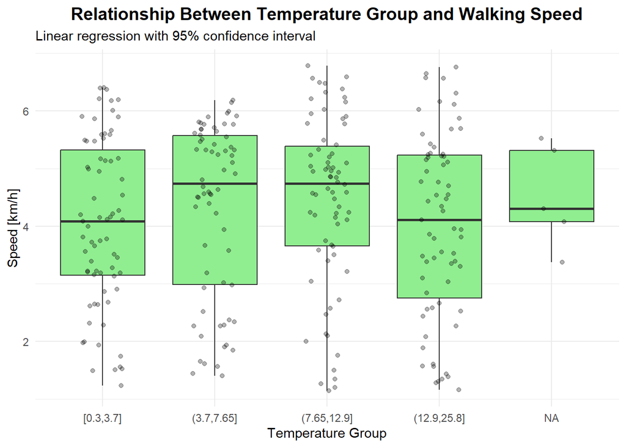

```r
# visualize
ggplot(segments_weather_clean, aes(x = temp_group, y = speed_kmh)) +

  geom_boxplot(fill = "lightgreen") +

  geom_jitter(width = 0.2, alpha = 0.3) +

  labs(
    x = "Temperature Group",
    y = "Speed [km/h]",
    title = "Relationship Between Temperature Group and Walking Speed",
    subtitle = "Linear regression with 95% confidence interval") +

  theme_minimal() +

  theme(
    plot.title = element_text(size = 14, face = "bold", hjust = 0.5),
    legend.title = element_text(size = 10),
    legend.text = element_text(size = 8)
    )
```

```r
# test if difference between temp_groups is significant
anova(lm(speed_kmh ~ temp_group, data = segments_weather_clean))
```

```
Analysis of Variance Table

Response: speed_kmh
            Df Sum Sq Mean Sq F value Pr(>F)
temp_group   3   9.62  3.2057  1.4109 0.2399
Residuals  270 613.47  2.2721
```

```r
# label bins
segments_weather_clean <- segments_weather_clean |>
  mutate(temp_group = factor(temp_group,
                             levels = levels(temp_group),
                             labels = c("Cold (1-4°C)", "Cool (4-9°C)", "Mild (9-13°C)", "Warm (13-26°C)")))

# remove NA values
segments_weather_clean <- segments_weather_clean |>
  filter(!is.na(temp_group))
```

However, if we classify the segments into different temperature groups, a difference between the groups is visible. In general, higher temperatures are associated with lower walking speed, from 4.8km/h for cool temperatures to almost 4km/h for warm temperatures, except for very cold temperatures, where also slow walking speeds are identified.

The median walking speed varies modestly across temperature groups (4.1–4.8 km/h), but due to the large within-group spread this difference is not statistically significant (p-value = 0.24).

### A) City-level Analysis

Based on the city-level weather data, we clearly see that with increasing rain duration, walking speed is reduced.

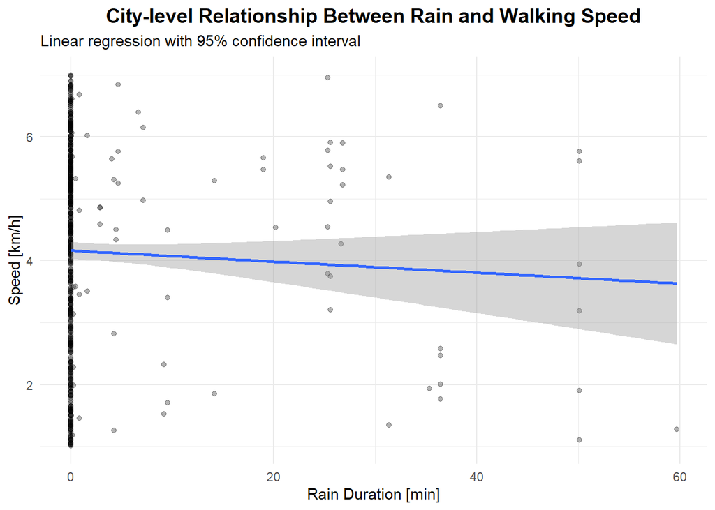

```r
# visualize
ggplot(analysis_city, aes(rain, speed_kmh)) +

  geom_point(alpha = 0.3) +

  geom_smooth(method = "lm") +

  labs(
    x = "Rain Duration [min]",
    y = "Speed [km/h]",
    title = "City-level Relationship Between Rain and Walking Speed",
    subtitle = "Linear regression with 95% confidence interval") +

  theme_minimal() +

  theme(
    plot.title = element_text(size = 14, face = "bold", hjust = 0.5),
    legend.title = element_text(size = 10),
    legend.text = element_text(size = 8)
    )
```

### B) Station-level Analysis

Similarly to the city-level data, a negative trend is visible. However, with station-level weather data this trend is more pronounced, where with high precipitation duration walking speeds are below 3km/h.

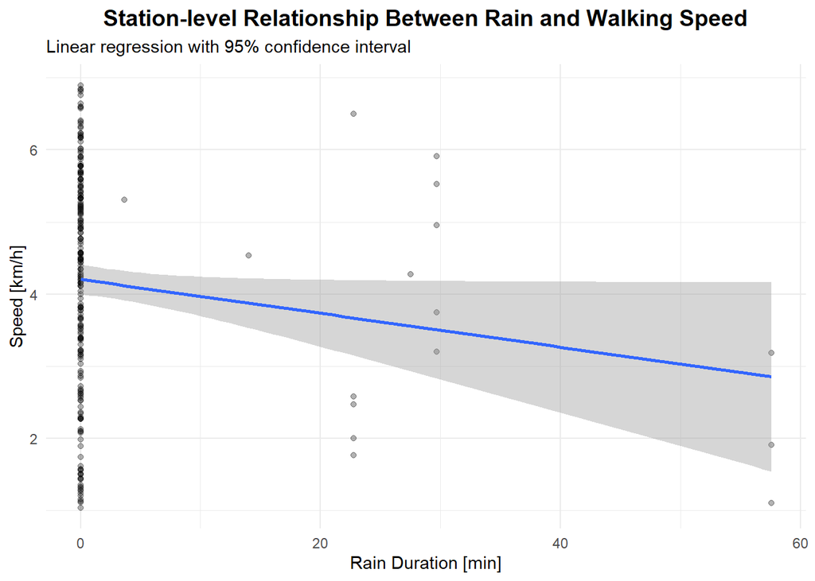

```r
# visualize
ggplot(analysis_station, aes(Wert, speed_kmh)) +

  geom_point(alpha = 0.3) +

  geom_smooth(method = "lm") +

  labs(
    x = "Rain Duration [min]",
    y = "Speed [km/h]",
    title = "Station-level Relationship Between Rain and Walking Speed",
    subtitle = "Linear regression with 95% confidence interval") +

  theme_minimal() +

  theme(
    plot.title = element_text(size = 14, face = "bold", hjust = 0.5),
    legend.title = element_text(size = 10),
    legend.text = element_text(size = 8)
    )
```

The relationship between speed and rain is also tested using a wilcox test. With a p-value of 0.2229, no significant relationship can be found.

```r
# test if significant relationship
wilcox.test(speed_kmh ~ rain_flag, data = analysis_data)
```

```
    Wilcoxon rank sum test with continuity correction

data:  speed_kmh by rain_flag
W = 2016, p-value = 0.2229
alternative hypothesis: true location shift is not equal to 0
```

```r
# see if relationship
lm(speed_kmh ~ Wert, data = analysis_data)
```

```
Call:
lm(formula = speed_kmh ~ Wert, data = analysis_data)

Coefficients:
(Intercept)         Wert
     4.2049      -0.0235
```

If we only include actual raining values (>0) for the fitting line, the relationship becomes even more visible.

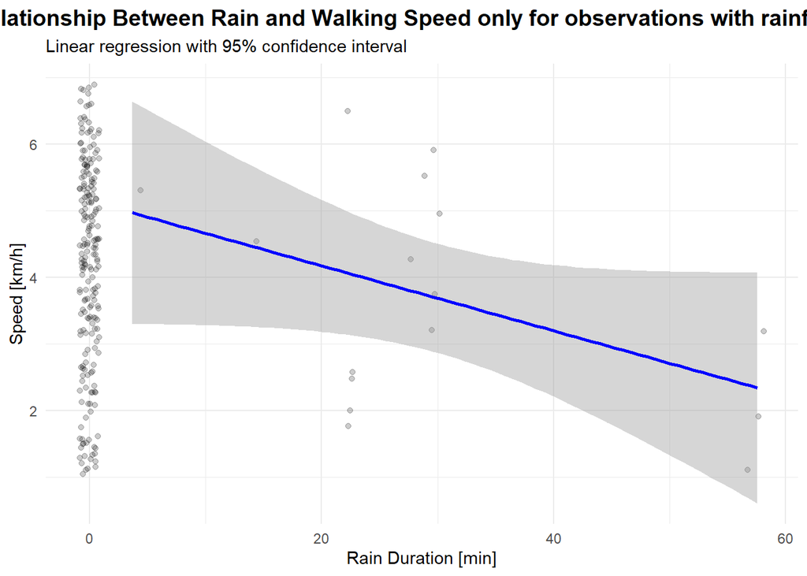

```r
# visualize, but only values where there actually is rain (>0)
ggplot(analysis_data, aes(Wert, speed_kmh)) +

  geom_jitter(alpha = 0.2, height = 0) +

  geom_smooth(
    data = filter(analysis_data, Wert > 0),
    method = "lm",
    color = "blue") +

  labs(
    x = "Rain Duration [min]",
    y = "Speed [km/h]",
    title = "Relationship Between Rain and Walking Speed only for observations with rainfall > 0",
    subtitle = "Linear regression with 95% confidence interval ") +

  theme_minimal() +

  theme(
    plot.title = element_text(size = 14, face = "bold", hjust = 0.5),
    legend.title = element_text(size = 10),
    legend.text = element_text(size = 8)
    )
```

# Discussion

## RQ1: How does temperature affect walking speed?

On the first sight, it seems that there is no relationship between temperature and walking speed. However, when dividing the segments into temperature groups, clear differences become visible. In general, higher temperatures are associated with lower walking speed, from 4.8km/h for cool temperatures to almost 4km/h for warm temperatures except for very cold temperatures, where also slow walking speeds are identified. Since the coldest temperatures are close to zero, a possible explanation for the low speed with cold temperatures is the increased caution and thus reduced velocity due to an elevated danger of slipping. These patterns are in line with previous research, which highlighted a certain increase in walking with higher temperatures, while very cold conditions could lead to slower speeds (Montigny, Ling, and Zacharias (2012); Giannoulaki and Christoforou (2024)), as type of u-shaped curve (Yerkes and Dodson (1908)). However, the relationship did not prove to be significant, which is likely due to the small set of trajectories.

## RQ2: How does precipitation affect walking speed?

Contrary to our expectations, increasing precipitation duration is associated with lower walking velocity. We hypothesized similarly to Giannoulaki and Christoforou (2024) that pedestrians would increase their speed under unfavourable weather to minimize exposure. However, other studies argue that precipitation reduces similarly to snow pavement quality and thus implies slower movement patterns. (Montigny, Ling, and Zacharias (2012); Giannoulaki and Christoforou (2024)). Overall, due to the very small amount of rain data caused by dry months and two stations not collecting any rain data, this part of the research question can not be adequately answered.

## RQ4: Do different temporal and spatial scales of the weather data matter?

### B) Spatial

The comparison between the analysis with city-level and with station-level weather data, revealed that it can have an effect on the quantification of the relationship. Although in both cases a negative relationship between precipitation and walking speed was identified, the station-level analysis showed a more clear trend. This can be likely explained by closer matching of weather stations to a certain segment.

## Limitations

This analysis has various limitations. First, the classification of segments with static thresholds into movement vs. non-movement is frequent, but recent research has shown that the selection of static thresholds is often not adequate and makes no distinction between different use cases. The proposed alternative would be a more flexible and user-adapted approach, which however is out of scope for this project (Bonavita, Guidotti, and Nanni (2022)).

Second, the low amount of trajectory and weather data means that our findings need to be interpreted with caution. This is especially the case for the analysis with precipitation data, as very few entries were available due to unusual dry conditions. Thus, the conducted tests and regression analysis have very limited power.

Third, important behavioural and environmental factors were not included. Trip purpose is likely a major determinant of mobility patterns, as walking behaviour is strongly driven by daily routines and situational needs (Montigny, Ling, and Zacharias (2012)). Additional influences such as sunlight, storms, weather complexity and urban context may also affect walking speed and behaviour (Giannoulaki and Christoforou (2024); Rotton, Shats, and Standers (1990); Shuichi et al. (2021)). Moreover, precipitation effects may vary over time, including delayed or anticipatory responses (Zhao et al. (2019)).

Fourth, data limitations remain in the movement representation itself, as noted in Methods (SDE). Additionally, concave hulls were calculated at daily scale only, even when weather data was available at finer resolutions, but this was a necessary simplification to maintain comparability across analyses. Also, rain duration does not capture rain intensity, which arguably might be even more important. Finally, we introduced a bias when we filtered our movements to the city of Zurich because when the weather is nice, we might have even moved out of the canton, increasing our movement space.

# AI Statement

LLMs were used to improve the structure of sentences and grammar as well as creating and debugging code, especially for content and challenges that go beyond the scope of the course. All content, analysis, and arguments remain the author’s own and any information derived from external sources is properly cited.

# Appendix

### Wordcount

Disclaimer: To improve structure and clarity, We included headings and subheadings for the whole report, which are around 1800 characters. That is why the total number of characters is slightly over the maximum number of characters.

```r
wordcountaddin::word_count("index.qmd") # counts words
```

```
[1] 3265
```

```r
wordcountaddin::text_stats("index.qmd") # counts characters
```

| Method | koRpus | stringi |
| --- | --- | --- |
| Word count | 3265 | 3235 |
| Character count | 21552 | 21518 |
| Sentence count | 219 | Not available |
| Reading time | 16.3 minutes | 16.2 minutes |

## References

Bonavita, Andrea, Riccardo Guidotti, and Mirco Nanni. 2022. “Individual and Collective Stop-Based Adaptive Trajectory Segmentation.” *Geoinformatica* 26 (3): 451–77. https://doi.org/10.1007/s10707-021-00449-8.

Giannoulaki, Maria, and Zoi Christoforou. 2024. “Pedestrian Walking Speed Analysis: A Systematic Review.” *Sustainability* 16 (11): 4813.

Guo, Sini, Xiang Li, Wai-Ki Ching, Ralescu Dan, Wai-Keung Li, and Zhiwen Zhang. 2018. “GPS Trajectory Data Segmentation Based on Probabilistic Logic.” *International Journal of Approximate Reasoning* 103: 227–47.

Laube, Patrick. 2009. “Progress in Movement Pattern Analysis.” In *Behaviour Monitoring and Interpretation - BMI - Smart Environments*, edited by Björn Gottfried and Hamid Aghajan, 43–71. Amsterdam, The Netherlands: IOS Press.

Laube, Patrick, and Ross S Purves. 2011. “How Fast Is a Cow? Cross-Scale Analysis of Movement Data.” *Transactions in GIS* 15 (3): 401–18.

Montigny, Luc de, Richard Ling, and John Zacharias. 2012. “The Effects of Weather on Walking Rates in Nine Cities.” *Environment and Behavior* 44 (November): 821–40. https://doi.org/10.1177/0013916511409033.

Nathan, Ran, Wayne M Getz, Eloy Revilla, Marcel Holyoak, Ronen Kadmon, David Saltz, and Peter E Smouse. 2008. “A Movement Ecology Paradigm for Unifying Organismal Movement Research.” *Proceedings of the National Academy of Sciences* 105 (49): 19052–59.

Rotton, James, Mark Shats, and Robert Standers. 1990. “Temperature and Pedestrian Tempo: Walking Without Awareness.” *Environment and Behavior* 22 (5): 650–74.

Shuichi, Obuchi, Hisashi Kawai, Juan Garbalosa, Kazumasa Nishida, and Kenji Murakawa. 2021. “Walking Is Regulated by Environmental Temperature.” *Scientific Reports* 11 (June). https://doi.org/10.1038/s41598-021-91633-1.

Weibel, Robert. 2024. “Point Patterns - Polygon Delineation.” University of Zurich; Lecture slides, GEO 872 Advanced Spatial Analysis I.

Yerkes, Robert M., and John D. Dodson. 1908. “The Relation of Strength of Stimulus to Rapidity of Habit-Formation.” *Journal of Comparative Neurology and Psychology* 18 (5): 459–82. https://doi.org/https://doi-org.ezproxy.uzh.ch/10.1002/cne.920180503.

Zhao, Jinbao, Cong Guo, Ruhua Zhang, Dong Guo, and Mathew Palmer. 2019. “Impacts of Weather on Cycling and Walking on Twin Trails in Seattle.” *Transportation Research Part D: Transport and Environment* 77: 573–88.